# Math 3B: Question-Level Analysis with Mixed-Effects Models

Xiao Long

2026-03-11

```r
library(tidyverse)
library(ggplot2)
library(dplyr)
library(readxl)
library(lme4)
library(broom.mixed)
```

## Overview

This notebook extends the student-level analysis by working at the **question level** — each row represents a single student attempt on a single question. This finer granularity reveals patterns in how time-on-task, attempt behavior, and topic area jointly predict question performance, while accounting for the nested structure of the data (questions nested within students).

**Research questions:**

1. Which topics (zones) are most difficult for students?
2. Does time spent on a question predict performance?
3. After accounting for individual student differences, what question-level factors drive scores?

## Data Overview

```r
df_raw <- read_excel("../data/FA25 Math 3B Data Mar9.xlsx", sheet = 2)
df_raw %>% glimpse()
```

```
## Rows: 43,698
## Columns: 22
## $ ID                         <dbl> 3971988, 3971988, 3971988, 3971988, 3971988…
## $ Role                       <chr> "Student", "Student", "Student", "Student",…
## $ Assessment                 <chr> "Practice Quiz 1", "Practice Quiz 1", "Prac…
## $ `Assessment instance`      <dbl> 1, 1, 1, 1, 1, 1, 2, 2, 2, 2, 2, 2, 1, 1, 1…
## $ `Zone number`              <dbl> 2, 2, 1, 1, 2, 1, 2, 2, 1, 1, 2, 1, 2, 2, 1…
## $ `Zone title`               <chr> "Domain and Range", "Domain and Range", "Fu…
## $ Question                   <chr> "3b/functions/domain-02", "3b/functions/dom…
## $ `Question instance`        <lgl> NA, NA, NA, NA, NA, NA, NA, NA, NA, NA, NA,…
## $ `Question points`          <dbl> 1, 1, 2, 2, 1, 1, 0, 0, 2, 0, 0, 0, 0, 0, 0…
## $ `Max points`               <dbl> 1, 1, 2, 2, 1, 1, 1, 1, 2, 2, 1, 1, 1, 1, 2…
## $ `Question % score`         <dbl> 100, 100, 100, 100, 100, 100, 0, 0, 100, 0,…
## $ `Auto points`              <dbl> 1, 1, 2, 2, 1, 1, 0, 0, 2, 0, 0, 0, 0, 0, 0…
## $ `Max auto points`          <dbl> 1, 1, 2, 2, 1, 1, 1, 1, 2, 2, 1, 1, 1, 1, 2…
## $ `Manual points`            <dbl> 0, 0, 0, 0, 0, 0, 0, 0, 0, 0, 0, 0, 0, 0, 0…
## $ `Max manual points`        <dbl> 0, 0, 0, 0, 0, 0, 0, 0, 0, 0, 0, 0, 0, 0, 0…
## $ Date                       <chr> "2025-10-09T22:41:24-07", "2025-10-09T22:41…
## $ `Highest submission score` <dbl> 1.0, 1.0, 1.0, 1.0, 1.0, 1.0, NA, NA, 1.0, …
## $ `Last submission score`    <dbl> 1.0, 1.0, 1.0, 1.0, 1.0, 1.0, NA, NA, 1.0, …
## $ `Number attempts`          <dbl> 1, 2, 1, 2, 1, 1, 0, 0, 1, 0, 0, 0, 3, 3, 3…
## $ `Duration seconds`         <dbl> 267.84830, 232.57358, 452.58163, 246.81332,…
## $ `Assigned manual grader`   <lgl> NA, NA, NA, NA, NA, NA, NA, NA, NA, NA, NA,…
## $ `Last manual grader`       <lgl> NA, NA, NA, NA, NA, NA, NA, NA, NA, NA, NA,…
```

```r
dim(df_raw)
```

```
## [1] 43698    22
```

Each row is one student–question interaction. Key variables: `ID` (student), `Question`, `Zone title` (topic area), `Duration seconds` (time spent), `Question % score`, `Number attempts`.

## Exploratory Analysis

### Score and Time Distribution

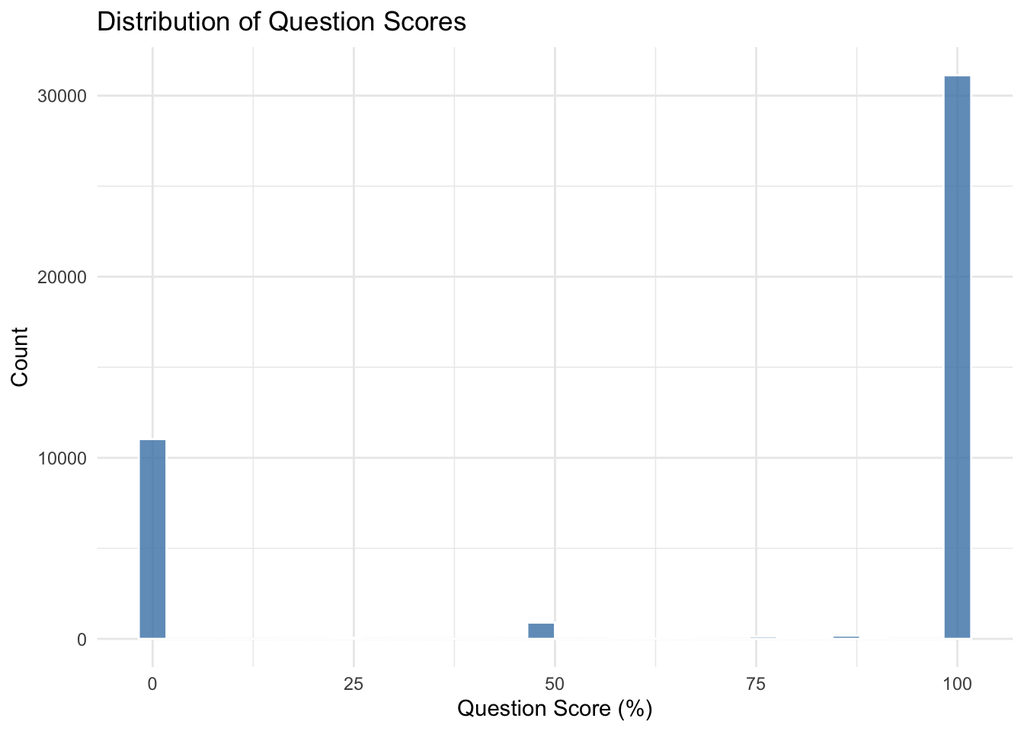

```r
ggplot(df_raw, aes(x = `Question % score`)) +
  geom_histogram(bins = 30, fill = "steelblue", alpha = 0.8, color = "white") +
  labs(
    title = "Distribution of Question Scores",
    x = "Question Score (%)",
    y = "Count"
  ) +
  theme_minimal()
```

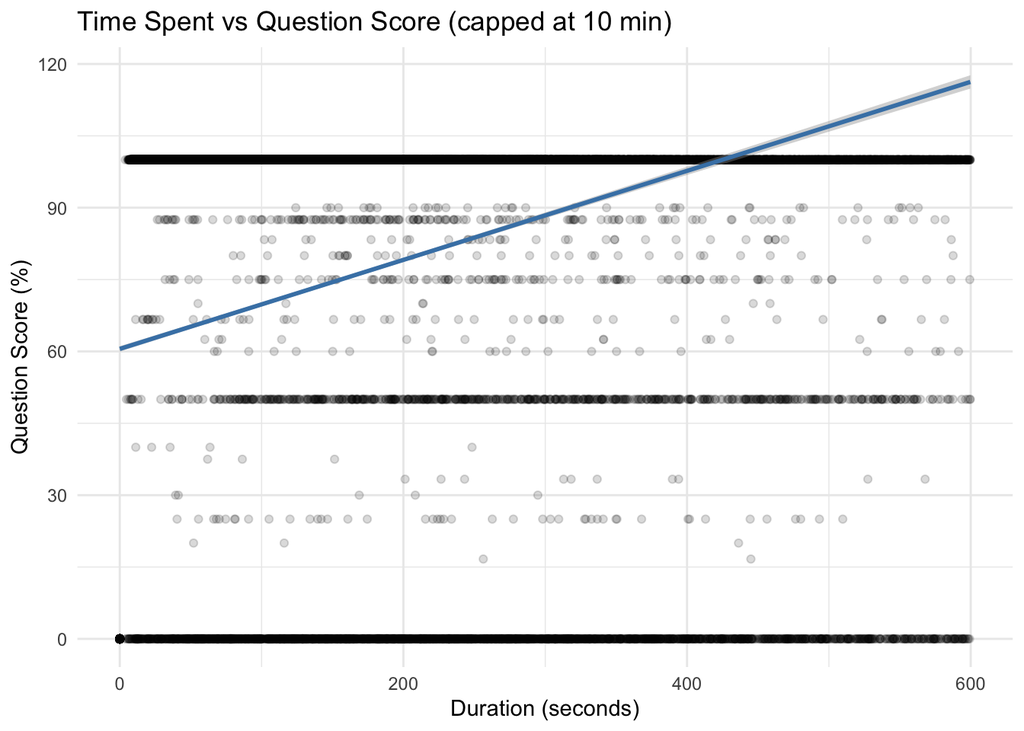

```r
df_raw %>%
  filter(`Duration seconds` < 600) %>%
  ggplot(aes(x = `Duration seconds`, y = `Question % score`)) +
  geom_point(alpha = 0.15) +
  geom_smooth(method = "lm", color = "steelblue") +
  labs(
    title = "Time Spent vs Question Score (capped at 10 min)",
    x = "Duration (seconds)",
    y = "Question Score (%)"
  ) +
  theme_minimal()
```

A modest positive relationship exists between time spent and question score, with wide variability. Very short durations tend to correspond to both very high scores (quick correct answers) and very low scores (quick guesses or skips).

## Topic-Level Performance

### Average Score by Topic Area

```r
zone_summary <- df_raw %>%
  group_by(`Zone title`) %>%
  summarise(
    avg_score   = mean(`Question % score`, na.rm = TRUE),
    avg_time    = mean(`Duration seconds`, na.rm = TRUE),
    avg_attempts = mean(`Number attempts`, na.rm = TRUE),
    n           = n()
  ) %>%
  arrange(avg_score)

zone_summary
```

```
## # A tibble: 17 × 5
##    `Zone title`                 avg_score avg_time avg_attempts     n
##    <chr>                            <dbl>    <dbl>        <dbl> <int>
##  1 Linear Systems                    60.4    222.         1.11   1150
##  2 Rational Functions                62.3    234.         1.26   1028
##  3 Rational Inequalities             64.9    182.         1.33   1725
##  4 Linear Functions                  68.2    231.         1.22   5272
##  5 Domain and Range                  68.7    151.         1.40   3522
##  6 Solving Quadratic Equations       69.2    223.         1.24   3912
##  7 Quadratic Word Problems           70.1    180.         0.962  3378
##  8 Rational Equations                70.3    185.         1.15   3161
##  9 Quadratic Functions               72.9    156.         1.17   3027
## 10 Polynomial Graphs                 73.1    186.         1.36   1908
## 11 Solve the Equations               75.9    186.         1.18   3027
## 12 Functions                         79.1    129.         1.06   3522
## 13 Uniform Motion                    80.5    179.         1.09   1784
## 14 Transformations of Functions      81.3     98.3        1.21   2636
## 15 Mixing Problem / Coins            83.0    257.         1.14    892
## 16 Polynomial Functions              86.5    161.         1.42   2862
## 17 Linear Modeling                   88.5    202.         1.37    892
```

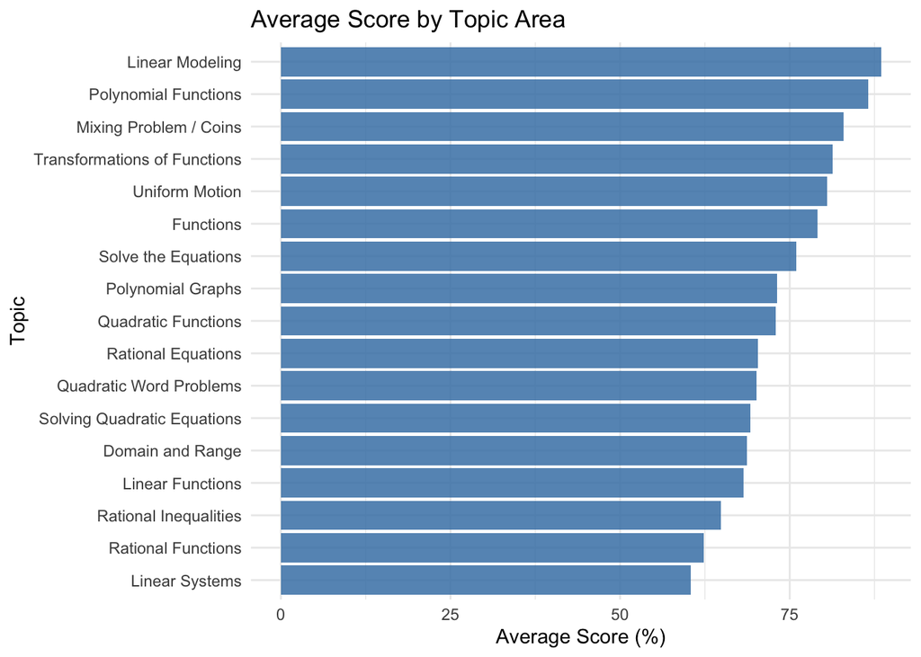

```r
ggplot(zone_summary, aes(x = reorder(`Zone title`, avg_score), y = avg_score)) +
  geom_col(fill = "steelblue", alpha = 0.85) +
  coord_flip() +
  labs(
    title = "Average Score by Topic Area",
    x = "Topic",
    y = "Average Score (%)"
  ) +
  theme_minimal()
```

Clear differences in difficulty across topic areas. This motivates including `Zone title` as a predictor in the regression models.

### Hardest Individual Questions

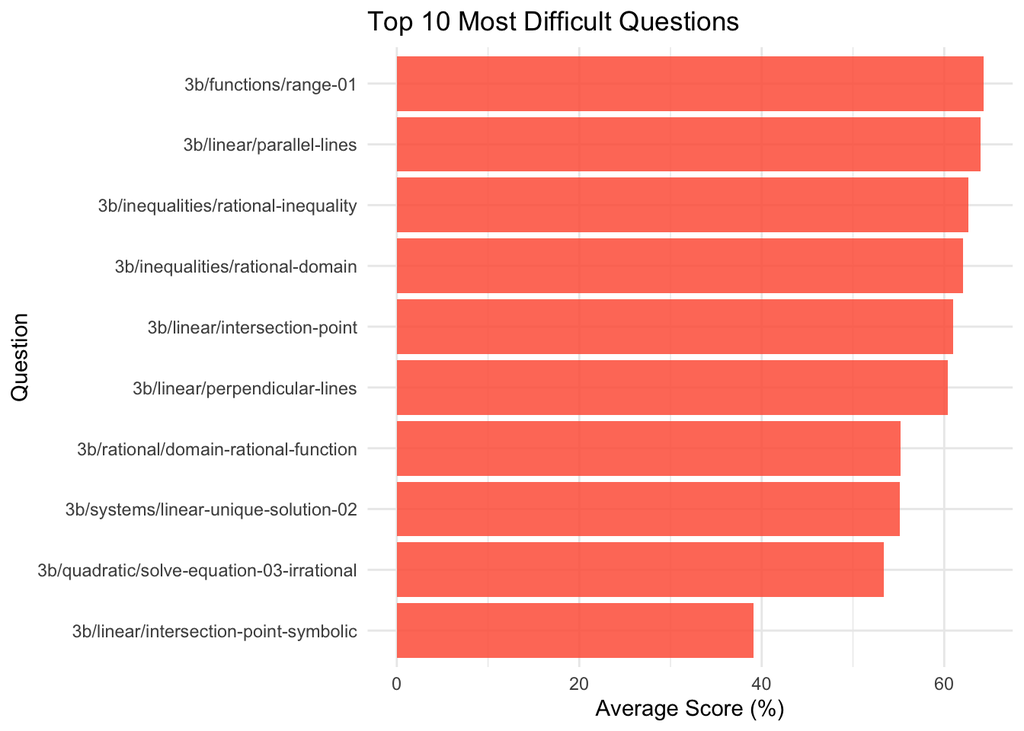

```r
question_summary <- df_raw %>%
  group_by(Question) %>%
  summarise(
    avg_score    = mean(`Question % score`, na.rm = TRUE),
    avg_time     = mean(`Duration seconds`, na.rm = TRUE),
    avg_attempts = mean(`Number attempts`, na.rm = TRUE),
    n            = n()
  ) %>%
  arrange(avg_score)

top10_hard <- question_summary %>% slice(1:10)

ggplot(top10_hard, aes(x = reorder(Question, avg_score), y = avg_score)) +
  geom_col(fill = "tomato", alpha = 0.85) +
  coord_flip() +
  labs(
    title = "Top 10 Most Difficult Questions",
    x = "Question",
    y = "Average Score (%)"
  ) +
  theme_minimal()
```

## OLS Regression (Baseline)

Before fitting the mixed-effects model, we establish an OLS baseline to assess the raw predictive power of time, attempts, and topic.

```r
df_clean <- df_raw %>%
  filter(`Duration seconds` < 600)

model_ols <- lm(
  `Question % score` ~ `Duration seconds` + `Number attempts` + `Zone title`,
  data = df_clean
)
summary(model_ols)
```

```
##
## Call:
## lm(formula = `Question % score` ~ `Duration seconds` + `Number attempts` +
##     `Zone title`, data = df_clean)
##
## Residuals:
##     Min      1Q  Median      3Q     Max
## -129.89  -42.84   19.30   29.38   49.79
##
## Coefficients:
##                                           Estimate Std. Error t value Pr(>|t|)
## (Intercept)                              48.373525   0.760370  63.618  < 2e-16
## `Duration seconds`                        0.065509   0.001789  36.621  < 2e-16
## `Number attempts`                         9.183023   0.287309  31.962  < 2e-16
## `Zone title`Functions                    14.356865   0.978789  14.668  < 2e-16
## `Zone title`Linear Functions              0.785112   0.911477   0.861 0.389044
## `Zone title`Linear Modeling              16.569080   1.546742  10.712  < 2e-16
## `Zone title`Linear Systems               -8.377444   1.429339  -5.861 4.63e-09
## `Zone title`Mixing Problem / Coins       12.791048   1.581386   8.089 6.20e-16
## `Zone title`Polynomial Functions         16.988304   1.033109  16.444  < 2e-16
## `Zone title`Polynomial Graphs             2.361844   1.169161   2.020 0.043378
## `Zone title`Quadratic Functions           5.786410   1.019134   5.678 1.37e-08
## `Zone title`Quadratic Word Problems       3.513467   1.002164   3.506 0.000456
## `Zone title`Rational Equations            1.744942   1.014052   1.721 0.085302
## `Zone title`Rational Functions           -9.568629   1.497508  -6.390 1.68e-10
## `Zone title`Rational Inequalities        -5.534269   1.209481  -4.576 4.76e-06
## `Zone title`Solve the Equations           7.076526   1.024479   6.907 5.01e-12
## `Zone title`Solving Quadratic Equations  -0.444375   0.968901  -0.459 0.646496
## `Zone title`Transformations of Functions 16.828744   1.052551  15.989  < 2e-16
## `Zone title`Uniform Motion               13.648943   1.204101  11.335  < 2e-16
##
## (Intercept)                              ***
## `Duration seconds`                       ***
## `Number attempts`                        ***
## `Zone title`Functions                    ***
## `Zone title`Linear Functions
## `Zone title`Linear Modeling              ***
## `Zone title`Linear Systems               ***
## `Zone title`Mixing Problem / Coins       ***
## `Zone title`Polynomial Functions         ***
## `Zone title`Polynomial Graphs            *
## `Zone title`Quadratic Functions          ***
## `Zone title`Quadratic Word Problems      ***
## `Zone title`Rational Equations           .
## `Zone title`Rational Functions           ***
## `Zone title`Rational Inequalities        ***
## `Zone title`Solve the Equations          ***
## `Zone title`Solving Quadratic Equations
## `Zone title`Transformations of Functions ***
## `Zone title`Uniform Motion               ***
## ---
## Signif. codes:  0 '***' 0.001 '**' 0.01 '*' 0.05 '.' 0.1 ' ' 1
##
## Residual standard error: 40.27 on 41257 degrees of freedom
## Multiple R-squared:  0.1423, Adjusted R-squared:  0.1419
## F-statistic: 380.2 on 18 and 41257 DF,  p-value: < 2.2e-16
```

## Mixed-Effects Model

To properly account for the nested data structure — multiple question attempts per student — we fit a linear mixed-effects model with a random intercept for each student. This separates within-student effects (how question features affect a given student’s score) from between-student differences in baseline performance.

```r
model_mixed <- lmer(
  `Question % score` ~ `Duration seconds` + `Number attempts` + `Zone title` + (1 | ID),
  data = df_clean
)
summary(model_mixed)
```

```
## Linear mixed model fit by REML ['lmerMod']
## Formula: `Question % score` ~ `Duration seconds` + `Number attempts` +
##     `Zone title` + (1 | ID)
##    Data: df_clean
##
## REML criterion at convergence: 417796.3
##
## Scaled residuals:
##     Min      1Q  Median      3Q     Max
## -3.6330 -0.7304  0.3263  0.7030  2.2598
##
## Random effects:
##  Groups   Name        Variance Std.Dev.
##  ID       (Intercept)  220.4   14.85
##  Residual             1430.2   37.82
## Number of obs: 41276, groups:  ID, 268
##
## Fixed effects:
##                                            Estimate Std. Error t value
## (Intercept)                               49.335744   1.178969  41.847
## `Duration seconds`                         0.062176   0.001757  35.394
## `Number attempts`                          8.443434   0.279063  30.256
## `Zone title`Functions                     14.000891   0.919400  15.228
## `Zone title`Linear Functions              -1.100761   0.865904  -1.271
## `Zone title`Linear Modeling               14.701351   1.459534  10.073
## `Zone title`Linear Systems                -7.287430   1.361213  -5.354
## `Zone title`Mixing Problem / Coins        10.854199   1.492576   7.272
## `Zone title`Polynomial Functions          15.079774   0.983508  15.333
## `Zone title`Polynomial Graphs              0.468334   1.109655   0.422
## `Zone title`Quadratic Functions            4.480037   0.969601   4.620
## `Zone title`Quadratic Word Problems        1.665080   0.953517   1.746
## `Zone title`Rational Equations             0.595024   0.969029   0.614
## `Zone title`Rational Functions           -10.374424   1.427389  -7.268
## `Zone title`Rational Inequalities         -4.069673   1.158047  -3.514
## `Zone title`Solve the Equations            5.854765   0.974481   6.008
## `Zone title`Solving Quadratic Equations   -2.075847   0.923146  -2.249
## `Zone title`Transformations of Functions  14.729763   0.996897  14.776
## `Zone title`Uniform Motion                11.506251   1.140408  10.090
```

The random intercept for `ID` captures stable individual differences in student performance. Fixed effects then estimate the within-student associations between time, attempt behavior, topic area, and question score.

## Random Effects: Student Heterogeneity

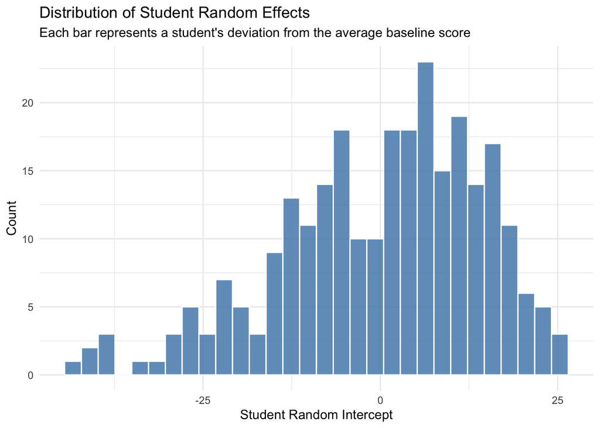

```r
student_re <- ranef(model_mixed)$ID %>%
  rownames_to_column(var = "ID") %>%
  rename(random_intercept = `(Intercept)`)

ggplot(student_re, aes(x = random_intercept)) +
  geom_histogram(bins = 30, fill = "steelblue", alpha = 0.8, color = "white") +
  labs(
    title = "Distribution of Student Random Effects",
    subtitle = "Each bar represents a student's deviation from the average baseline score",
    x = "Student Random Intercept",
    y = "Count"
  ) +
  theme_minimal()
```

The distribution of random intercepts is approximately normal and centered near zero, confirming that some students consistently outperform or underperform the average, independent of question-level features. This validates the use of mixed-effects modeling over standard OLS.